# Ryan Tillis - R Programming - Hospital Quality - Coursera

[Ryan Tillis](http://www.ryantillis.com)

7/1/2016

## Summary

The goal of this project is to write function which take hospital data to return the best, worst and ranking number of the hospitals given certain criteria. I wrote one version using for loops and one without using for loops.

## Plot the 30-day mortality rates for heart attack

```r
rates <- read.csv("outcome-of-care-measures.csv", colClasses = "character")
```

There are many columns in this dataset. You can see how many by typing ncol(outcome) (you can see the number of rows with the nrow function). In addition, you can see the names of each column by typing names(outcome) (the names are also in the PDF document. To make a simple histogram of the 30-day death rates from heart attack (column 11 in the outcome dataset), run

```
## Warning in hist(as.numeric(rates[, 11])): NAs introduced by coercion
```

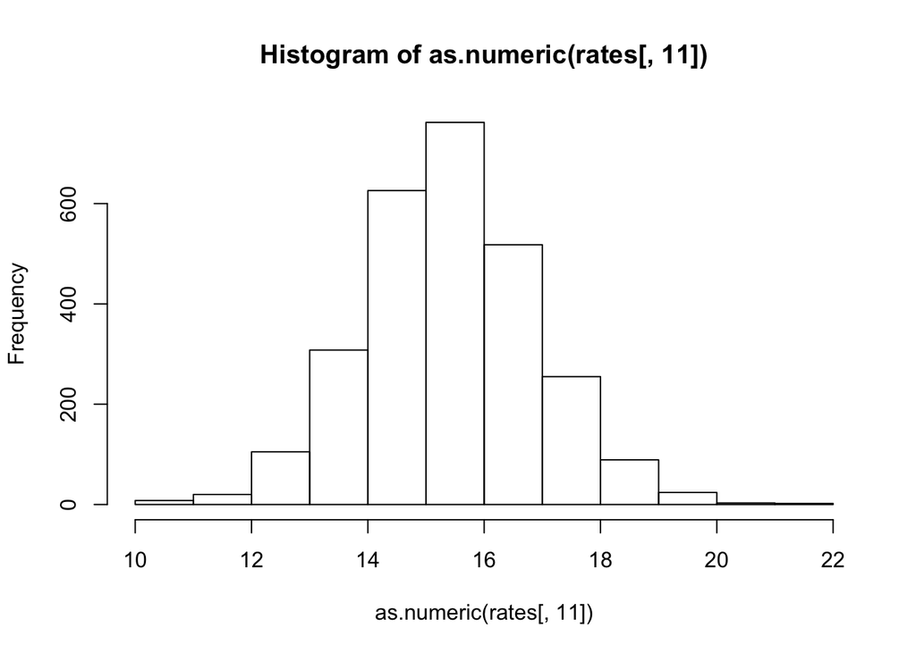

```r
## You may get a warning about NAs being introduced; that is okay
hist(as.numeric(rates[, 11]))
```

Because we originally read the data in as character (by specifying colClasses = “character” we need to coerce the column to be numeric. You may get a warning about NAs being introduced but that is okay.

#### Submission

```r
url = "https://d396qusza40orc.cloudfront.net/rprog%2Fdata%2FProgAssignment3-data.zip"
download.file(url, destfile = "temp")
unzip("temp")
unlink("temp")
```

## Finding the best hospital in a state

Write a function called best that take two arguments: the 2-character abbreviated name of a state and an outcome name. The function reads the outcome-of-care-measures.csv file and returns a character vector with the name of the hospital that has the best (i.e. lowest) 30-day mortality for the specified outcome in that state. The hospital name is the name provided in the Hospital.Name variable. The outcomes can be one of “heart attack”, “heart failure”, or “pneumonia”. Hospitals that do not have data on a particular outcome should be excluded from the set of hospitals when deciding the rankings.

Handling ties. If there is a tie for the best hospital for a given outcome, then the hospital names should be sorted in alphabetical order and the first hospital in that set should be chosen (i.e. if hospitals “b”, “c”, and “f” are tied for best, then hospital “b” should be returned). The function should use the following template.

```r
best <- function(state, outcome) {
        ## Read outcome data

       ## Check that state and outcome are valid
       ## Return hospital name in that state with lowest 30-day death
       ## rate
}
```

The function should check the validity of its arguments. If an invalid state value is passed to best, the function should throw an error via the stop function with the exact message “invalid state”. If an invalid outcome value is passed to best, the function should throw an error via the stop function with the exact message “invalid outcome”. Here is some sample output from the function.

#### Submission

```r
require(plyr)
hosp_sort <- function(state,outcome){
       #setting NA to be 0
       rates[rates == "Not Available"] <- 0
       index <- c(grep("^Hospital.*Death*", names(rates)))
       mortality_rates <- rates[,c(2,7,index)]
       names(mortality_rates)[3:5] <- c("heart attack", "heart failure", "pneumonia")

       #Making rates numeric
       mortality_rates[,3:5] <- apply(mortality_rates[,3:5],2,as.numeric)

       mortality_rates[mortality_rates == 0] <- NA
       selected_state <- mortality_rates[mortality_rates$State == state,]

       order_selected <- arrange(selected_state, selected_state[,outcome], Hospital.Name, na.last=TRUE)
       order_selected <- order_selected[complete.cases(order_selected[,outcome]),]
       return(order_selected)
        #na.omit(selected_state[order(c(selected_state[,outcome]), na.last = TRUE),])
}

best <- function(state, outcome, st = "a") {
       if (!state %in% unique(rates$State))
              return("Invalid State")
       if (!outcome %in% c("heart attack", "heart failure", "pneumonia"))
              return("Invalid Outcome")

       order_selected <- hosp_sort(state,outcome)
       return(order_selected[1,1])

}
```

#### Testing

```r
best("TX", "heart attack")
```

```
## [1] "CYPRESS FAIRBANKS MEDICAL CENTER"
```

```r
best("TX", "heart failure")
```

```
## [1] "FORT DUNCAN MEDICAL CENTER"
```

```r
best("MD", "heart attack")
```

```
## [1] "JOHNS HOPKINS HOSPITAL, THE"
```

```r
best("MD", "pneumonia")
```

```
## [1] "GREATER BALTIMORE MEDICAL CENTER"
```

```r
best("BB", "heart attack")
```

```
## [1] "Invalid State"
```

```r
best("NY", "hert attack")
```

```
## [1] "Invalid Outcome"
```

## Ranking hospitals by outcome in a state

Write a function called rankhospital that takes three arguments: the 2-character abbreviated name of a state (state), an outcome (outcome), and the ranking of a hospital in that state for that outcome (num). The function reads the outcome-of-care-measures.csv file and returns a character vector with the name of the hospital that has the ranking specified by the num argument. For example, the call

```r
rankhospital("MD", "heart failure", 5)
```

would return a character vector containing the name of the hospital with the 5th lowest 30-day death rate for heart failure. The num argument can take values “best”, “worst”, or an integer indicating the ranking (smaller numbers are better). If the number given by num is larger than the number of hospitals in that state, then the function should return NA. Hospitals that do not have data on a particular outcome should be excluded from the set of hospitals when deciding the rankings.

```r
head(texas)
```

[output not shown]

```r
rankhospital <- function(state, outcome, num = "best") {
        ## Read outcome data
       ## Check that state and outcome are valid
       ## Return hospital name in that state with the given rank
       ## 30-day death rate

}
```

The function should check the validity of its arguments. If an invalid state value is passed to best, the function should throw an error via the stop function with the exact message “invalid state”. If an invalid outcome value is passed to best, the function should throw an error via the stop function with the exact message “invalid outcome”.

#### Submission

```r
worst <- function(state, outcome, st = "a") {
       if (!state %in% unique(rates$State))
              return("Invalid State")
       if (!outcome %in% c("heart attack", "heart failure", "pneumonia"))
              return("Invalid Outcome")

       order_selected <- hosp_sort(state,outcome)

       return(order_selected[nrow(order_selected),1])
}

rankhospital <- function(state, outcome, num = "best", st = "a"){
       if (num == "best")
              return(best(state,outcome))
       if (num == "worst")
              return(worst(state,outcome))
       else {order_selected <- hosp_sort(state,outcome)
              return(order_selected[num,1])}
}
```

## Ranking hospitals in all states

Write a function called rankall that takes two arguments: an outcome name (outcome) and a hospital rank- ing (num). The function reads the outcome-of-care-measures.csv file and returns a 2-column data frame containing the hospital in each state that has the ranking specified in num. For example the function call rankall(“heart attack”, “best”) would return a data frame containing the names of the hospitals that are the best in their respective states for 30-day heart attack death rates. The function should return a value for every state (some may be NA). The first column in the data frame is named hospital, which contains the hospital name, and the second column is named state, which contains the 2-character abbreviation for the state name. Hospitals that do not have data on a particular outcome should be excluded from the set of hospitals when deciding the rankings. Handling ties. The rankall function should handle ties in the 30-day mortality rates in the same way that the rankhospital function handles ties. The function should use the following template.

```r
rankall <- function(outcome, num = "best") {
        ## Read outcome data
       ## Check that state and outcome are valid
       ## For each state, find the hospital of the given rank
       ## Return a data frame with the hospital names and the
       ## (abbreviated) state name
}
```

NOTE: For the purpose of this part of the assignment (and for efficiency), your function should NOT call the rankhospital function from the previous section.

The function should check the validity of its arguments. If an invalid outcome value is passed to rankall, the function should throw an error via the stop function with the exact message “invalid outcome”. The num variable can take values “best”, “worst”, or an integer indicating the ranking (smaller numbers are better). If the number given by num is larger than the number of hospitals in that state, then the function should return NA.

#### Submission

```r
hosp_sort <- function(state,outcome){
       #setting NA to be 0
       rates[rates == "Not Available"] <- 0
       index <- c(grep("^Hospital.*Death*", names(rates)))
       mortality_rates <- rates[,c(2,7,index)]
       names(mortality_rates)[3:5] <- c("heart attack", "heart failure", "pneumonia")

       #Making rates numeric
       mortality_rates[,3:5] <- apply(mortality_rates[,3:5],2,as.numeric)

       mortality_rates[mortality_rates == 0] <- NA
       selected_state <- mortality_rates[mortality_rates$State == state,]

       order_selected <- arrange(selected_state, selected_state[,outcome], Hospital.Name, na.last=TRUE)
       order_selected <- order_selected[complete.cases(order_selected[,outcome]),]
       return(order_selected)
        #na.omit(selected_state[order(c(selected_state[,outcome]), na.last = TRUE),])
}

best <- function(state, outcome, st = "a") {
       if (!state %in% unique(rates$State))
              return("Invalid State")
       if (!outcome %in% c("heart attack", "heart failure", "pneumonia"))
              return("Invalid Outcome")

       order_selected <- hosp_sort(state,outcome)
       return(order_selected[1,c(1,2)])

}

worst <- function(state, outcome, st = "a") {
       if (!state %in% unique(rates$State))
              return("Invalid State")
       if (!outcome %in% c("heart attack", "heart failure", "pneumonia"))
              return("Invalid Outcome")

       order_selected <- hosp_sort(state,outcome)

       return(order_selected[nrow(order_selected),c(1,2)])
}

rankhospital <- function(state, outcome, num = "best", st = "a"){
       if (num == "best")
              return(best(state,outcome))
       if (num == "worst")
              return(worst(state,outcome))
       else {order_selected <- hosp_sort(state,outcome)
              return(order_selected[num,c(1,2)])}
}

rankall <- function(outcome, num = "best") {
       #print(lapply(unique(rates$State),hosp_sort, outcome))
       results <- unlist(lapply(sort(unique(rates$State)), rankhospital, outcome, num),use.names=FALSE)
       hosp <- results[c(TRUE,FALSE)]
       state <- results[c(FALSE,TRUE)]
       all <- data.frame(hosp,state)
       names(all) <- c("Hospital.Name", "state")
       all

}
```

#### Testing

```r
head(rankall("heart attack", 20), 10)
```

```
##                          Hospital.Name state
## 1                                 <NA>  <NA>
## 2       D W MCMILLAN MEMORIAL HOSPITAL    AL
## 3    ARKANSAS METHODIST MEDICAL CENTER    AR
## 4  JOHN C LINCOLN DEER VALLEY HOSPITAL    AZ
## 5                SHERMAN OAKS HOSPITAL    CA
## 6             SKY RIDGE MEDICAL CENTER    CO
## 7              MIDSTATE MEDICAL CENTER    CT
## 8                                 <NA>  <NA>
## 9                                 <NA>  <NA>
## 10      SOUTH FLORIDA BAPTIST HOSPITAL    FL
```

```r
tail(rankall("pneumonia", "worst"), 3)
```

```
##                                 Hospital.Name state
## 52 MAYO CLINIC HEALTH SYSTEM - NORTHLAND, INC    WI
## 53                     PLATEAU MEDICAL CENTER    WV
## 54           NORTH BIG HORN HOSPITAL DISTRICT    WY
```

```r
tail(rankall("heart failure"), 10)
```

```
##                                                        Hospital.Name state
## 45                         WELLMONT HAWKINS COUNTY MEMORIAL HOSPITAL    TN
## 46                                        FORT DUNCAN MEDICAL CENTER    TX
## 47 VA SALT LAKE CITY HEALTHCARE - GEORGE E. WAHLEN VA MEDICAL CENTER    UT
## 48                                          SENTARA POTOMAC HOSPITAL    VA
## 49                            GOV JUAN F LUIS HOSPITAL & MEDICAL CTR    VI
## 50                                              SPRINGFIELD HOSPITAL    VT
## 51                                         HARBORVIEW MEDICAL CENTER    WA
## 52                                    AURORA ST LUKES MEDICAL CENTER    WI
## 53                                         FAIRMONT GENERAL HOSPITAL    WV
## 54                                        CHEYENNE VA MEDICAL CENTER    WY
```

## With For Loops

```r
rankhospital <- function(state, outcome, num = "best") {

       ## Read outcome data

       data <- read.csv("outcome-of-care-measures.csv", colClasses = "character")

       ## Check that state and outcome are valid

       states <- unique(data[, 7])
       outcomes <- c("heart attack", "heart failure", "pneumonia")

       if (!state %in% states) {
              stop("invalid state")
       }

       if (!outcome %in% outcomes) {
              stop("invalid outcome")
       }

       if (outcome == "heart attack") {
              outcome <- 11
       }

       if (outcome == "heart failure") {
              outcome <- 17
       }

       if (outcome == "pneumonia") {
              outcome <- 23
       }

       data[, 11] <- suppressWarnings(as.numeric(data[, 11])) # heart attack
       data[, 17] <- suppressWarnings(as.numeric(data[, 17])) # heart failure
       data[, 23] <- suppressWarnings(as.numeric(data[, 23])) # pneumonia

       stateframe <- data[data[, 7] == state, ]


       statesort <- stateframe[order(stateframe[outcome], stateframe[2]),]

       if (num == "best") {num <- 1}
       if (num == "worst") {
              num <- nrow(statesort)
              ret <- c(statesort[num, 2], state)
              return(ret)
              num = "worst"}
       else{
       ret <- c(statesort[num, 2], state)
       return(ret)
       }
       ## Return hospital name in that state with the given rank
       ## 30-day death rate

}


rankall <- function(outcome, num = "best") {

       data <- read.csv("outcome-of-care-measures.csv", colClasses = "character")

       ## Check that state and outcome are valid

       states <- sort(unique(data[, 7]))

       mat <- matrix(, nrow = 0, ncol = 2)

       hospital <- rep("", length(states))

       for (i in (1:length(states))) {
              out <- matrix(rankhospital(states[i], outcome, num), ncol = 2)
              mat <- rbind(mat, out)
       }

       mat

       }
```

See more at [my website.](http://www.ryantillis.com)